# South Africa Covid19

INTRODUCTION www.corona-stats.co.za launched a free API for historical South African COVID-19 data in April 2020. Data can be accessed using the link:"http://corona-stats.mobi/api/. This project entails accessing South African COVID-19 data from the API, compiling accessed data into useable datasets,Exploratory data analysis,data cleaning and representing the data in useable format i.e. data visualization utilizing Tableau.

1. DATA ACCESS To extract data from the API R programming language packages:httr and Jsonlite were used.

```r
library(httr)
library(jsonlite)
library(dplyr)

base_url = "http://corona-stats.mobi/api/"
info_url = "json.2.0.php?key=b1fQnVw3MoTAyqNmkigJ"
full_url = base::paste0(base_url,info_url)

api_call = httr::GET(full_url)
```

To check whether the request was successful the status code has to be 200. If it is around 400 it means the request was unsuccessful.

```r
api_call$status_code
```

```
[1] 200
```

Converting the response to usable format

```r
api_char = base::rawToChar(api_call$content)

str(api_char)

api_Json = jsonlite::fromJSON(api_char,flatten = T)

api_Json
str(api_Json)
Covid19_RSA = api_Json$RSA
```

The Covid19 data is in the RSA list.RSA contains 22 lists of South Africa Covid19 data.

```r
library(writexl)
```

2. Western Cape Data

```r
WC_data = Covid19_RSA$WC
Total_Cases = WC_data$Cases
Total_Recoveries = WC_data$Recoveries
Total_Deaths = WC_data$Deaths

Daily_Cases = WC_data$`Daily Cases`
Daily_Deaths = WC_data$`Daily Deaths`

Cases_14day_average = WC_data$`Daily Cases 14 day average`
Deaths_14day_average = WC_data$`Daily Deaths 14 day average`


WC_Covid19data = data.frame(Date=Dates1,Total_Cases,Total_Recoveries,Total_Deaths,Daily_Cases,Daily_Deaths,Cases_14day_average,Deaths_14day_average)

write_xlsx(WC_Covid19data,"WesternCapeCovid19.xlsx")
```

3. Gauteng Data

```r
Gauteng_data = Covid19_RSA$GP
Total_Cases = Gauteng_data$Cases
Total_Recoveries = Gauteng_data$Recoveries
Total_Deaths = Gauteng_data$Deaths

Daily_Cases = Gauteng_data$`Daily Cases`
Daily_Deaths = Gauteng_data$`Daily Deaths`

Cases_14day_average = Gauteng_data$`Daily Cases 14 day average`
Deaths_14day_average = Gauteng_data$`Daily Deaths 14 day average`


Gauteng_Covid19data = data.frame(Date=Dates1,Total_Cases,Total_Recoveries,Total_Deaths,Daily_Cases,Daily_Deaths,Cases_14day_average,Deaths_14day_average)

write_xlsx(Gauteng_Covid19data,"GautengCovid19.xlsx")
```

4. KZN Data

```r
KZN_data = Covid19_RSA$KZN
Total_Cases = KZN_data$Cases
Total_Recoveries = KZN_data$Recoveries
Total_Deaths = KZN_data$Deaths

Daily_Cases = KZN_data$`Daily Cases`
Daily_Deaths = KZN_data$`Daily Deaths`

Cases_14day_average = KZN_data$`Daily Cases 14 day average`
Deaths_14day_average = KZN_data$`Daily Deaths 14 day average`


KZN_Covid19data = data.frame(Date=Dates1,Total_Cases,Total_Recoveries,Total_Deaths,Daily_Cases,Daily_Deaths,Cases_14day_average,Deaths_14day_average)

write_xlsx(KZN_Covid19data,"KZNCovid19.xlsx")
```

5. Eastern Cape Data

```r
EC_data = Covid19_RSA$EC
Total_Cases = EC_data$Cases
Total_Recoveries = EC_data$Recoveries
Total_Deaths = EC_data$Deaths

Daily_Cases = EC_data$`Daily Cases`
Daily_Deaths = EC_data$`Daily Deaths`

Cases_14day_average = EC_data$`Daily Cases 14 day average`
Deaths_14day_average = EC_data$`Daily Deaths 14 day average`


EC_Covid19data = data.frame(Date=Dates1,Total_Cases,Total_Recoveries,Total_Deaths,Daily_Cases,Daily_Deaths,Cases_14day_average,Deaths_14day_average)

write_xlsx(EC_Covid19data,"ECCovid19.xlsx")
```

6. Free State Data

```r
FS_data = Covid19_RSA$FS
Total_Cases = FS_data$Cases
Total_Recoveries = FS_data$Recoveries
Total_Deaths = FS_data$Deaths

Daily_Cases = FS_data$`Daily Cases`
Daily_Deaths = FS_data$`Daily Deaths`

Cases_14day_average = FS_data$`Daily Cases 14 day average`
Deaths_14day_average = FS_data$`Daily Deaths 14 day average`


FS_Covid19data = data.frame(Date=Dates1,Total_Cases,Total_Recoveries,Total_Deaths,Daily_Cases,Daily_Deaths,Cases_14day_average,Deaths_14day_average)

write_xlsx(FS_Covid19data,"FSCovid19.xlsx")
```

7. Mpumalanga Data

```r
MP_data = Covid19_RSA$MP
Total_Cases = MP_data$Cases
Total_Recoveries = MP_data$Recoveries
Total_Deaths = MP_data$Deaths

Daily_Cases = MP_data$`Daily Cases`
Daily_Deaths = MP_data$`Daily Deaths`

Cases_14day_average = MP_data$`Daily Cases 14 day average`
Deaths_14day_average = MP_data$`Daily Deaths 14 day average`


MP_Covid19data = data.frame(Date=Dates1,Total_Cases,Total_Recoveries,Total_Deaths,Daily_Cases,Daily_Deaths,Cases_14day_average,Deaths_14day_average)

write_xlsx(MP_Covid19data,"MPCovid19.xlsx")
```

8. Limpopo Data

```r
LP_data = Covid19_RSA$LP
Total_Cases = LP_data$Cases
Total_Recoveries = LP_data$Recoveries
Total_Deaths = LP_data$Deaths

Daily_Cases = LP_data$`Daily Cases`
Daily_Deaths = LP_data$`Daily Deaths`

Cases_14day_average = LP_data$`Daily Cases 14 day average`
Deaths_14day_average = LP_data$`Daily Deaths 14 day average`


LP_Covid19data = data.frame(Date=Dates1,Total_Cases,Total_Recoveries,Total_Deaths,Daily_Cases,Daily_Deaths,Cases_14day_average,Deaths_14day_average)

write_xlsx(LP_Covid19data,"LPCovid19.xlsx")
```

1. North West Data

```r
NW_data = Covid19_RSA$NW
Total_Cases = NW_data$Cases
Total_Recoveries = NW_data$Recoveries
Total_Deaths = NW_data$Deaths

Daily_Cases = NW_data$`Daily Cases`
Daily_Deaths = NW_data$`Daily Deaths`

Cases_14day_average = NW_data$`Daily Cases 14 day average`
Deaths_14day_average = NW_data$`Daily Deaths 14 day average`


NW_Covid19data = data.frame(Date=Dates1,Total_Cases,Total_Recoveries,Total_Deaths,Daily_Cases,Daily_Deaths,Cases_14day_average,Deaths_14day_average)

write_xlsx(NW_Covid19data,"NWCovid19.xlsx")
```

10. Northern Cape Data

```r
NC_data = Covid19_RSA$NC
Total_Cases = NC_data$Cases
Total_Recoveries = NC_data$Recoveries
Total_Deaths = NC_data$Deaths

Daily_Cases = NC_data$`Daily Cases`
Daily_Deaths = NC_data$`Daily Deaths`

Cases_14day_average = NC_data$`Daily Cases 14 day average`
Deaths_14day_average = NC_data$`Daily Deaths 14 day average`


NC_Covid19data = data.frame(Date=Dates1,Total_Cases,Total_Recoveries,Total_Deaths,Daily_Cases,Daily_Deaths,Cases_14day_average,Deaths_14day_average)

write_xlsx(NC_Covid19data,"NCCovid19.xlsx")
```

All the provincial dataframes were combined into 1 dataset, Sa_ProvincialCOVID19.

2. EXPLORATORY DATA ANALYSIS

```r
library(funModeling)
```

A. Checking the total number of rows and columns

```r
nrow(mydata)
```

```
[1] 6867
```

```r
ncol(mydata)
```

```
[1] 9
```

B. Basic data profiling

```r
df_status(mydata)
```

| variable | q_zeros | p_zeros | q_na | p_na | q_inf | p_inf | type | unique |
| --- | --- | --- | --- | --- | --- | --- | --- | --- |
| Date | 0 | 0.00 | 0 | 0 | 0 | 0 | POSIXct/POSIXt | 763 |
| Province | 0 | 0.00 | 0 | 0 | 0 | 0 | character | 9 |
| Total_Cases | 130 | 1.89 | 0 | 0 | 0 | 0 | character | 6339 |
| Total_Recoveries | 441 | 6.42 | 0 | 0 | 0 | 0 | character | 4956 |
| Total_Deaths | 539 | 7.85 | 0 | 0 | 0 | 0 | character | 3529 |
| Daily_Cases | 261 | 3.80 | 0 | 0 | 0 | 0 | character | 1677 |
| Daily_Deaths | 2885 | 42.01 | 0 | 0 | 0 | 0 | character | 209 |
| Cases_14day_average | 215 | 3.13 | 0 | 0 | 0 | 0 | character | 1676 |
| Deaths_14day_average | 999 | 14.55 | 0 | 0 | 0 | 0 | character | 155 |

Columns q_zeros and p_zeros show the number of zeros and percentage of zeros per column respectively. Columns q_na and p_na show the number of na values and percentage of na values respectively.Column type shows the data types for all the columns. Some numerical values are read as characters above and also the date format needs to be changed.

| variable | q_zeros | p_zeros | q_na | p_na | q_inf | p_inf | type | unique |
| --- | --- | --- | --- | --- | --- | --- | --- | --- |
| Date | 0 | 0.00 | 0 | 0 | 0 | 0 | Date | 763 |
| Province | 0 | 0.00 | 0 | 0 | 0 | 0 | character | 9 |
| Total_Cases | 130 | 1.89 | 0 | 0 | 0 | 0 | numeric | 6339 |
| Total_Recoveries | 441 | 6.42 | 0 | 0 | 0 | 0 | numeric | 4956 |
| Total_Deaths | 539 | 7.85 | 0 | 0 | 0 | 0 | numeric | 3529 |
| Daily_Cases | 261 | 3.80 | 0 | 0 | 0 | 0 | numeric | 1677 |
| Daily_Deaths | 2885 | 42.01 | 0 | 0 | 0 | 0 | character | 209 |
| Cases_14day_average | 215 | 3.13 | 0 | 0 | 0 | 0 | numeric | 1676 |
| Deaths_14day_average | 999 | 14.55 | 0 | 0 | 0 | 0 | numeric | 155 |

```r
summary(mydata)
```

```
      Date              Province          Total_Cases      Total_Recoveries
 Min.   :2020-03-02   Length:6867        Min.   :      0   Min.   :      0
 1st Qu.:2020-09-08   Class :character   1st Qu.:  29556   1st Qu.:  24101
 Median :2021-03-18   Mode  :character   Median : 107447   Median :  95432
 Mean   :2021-03-18                      Mean   : 182930   Mean   : 169871
 3rd Qu.:2021-09-25                      3rd Qu.: 219700   3rd Qu.: 194145
 Max.   :2022-04-03                      Max.   :1210873   Max.   :1185359
  Total_Deaths    Daily_Cases      Daily_Deaths       Cases_14day_average
 Min.   :    0   Min.   : -876.0   Length:6867        Min.   :    0.0
 1st Qu.:  510   1st Qu.:   51.0   Class :character   1st Qu.:   62.5
 Median : 2691   Median :  174.0   Mode  :character   Median :  194.0
 Mean   : 5297   Mean   :  544.1                      Mean   :  540.9
 3rd Qu.: 9198   3rd Qu.:  509.0                      3rd Qu.:  512.0
 Max.   :21869   Max.   :17716.0                      Max.   :10940.0
 Deaths_14day_average
 Min.   : -4.00
 1st Qu.:  2.00
 Median :  6.00
 Mean   : 14.58
 3rd Qu.: 17.00
 Max.   :164.00
```

There appears to be an error in the Daily_Cases and Deaths_14day_average columns. The minimum values are negative and that needs to be rectified. All the negative numbers will be replaced by the variable’s absolute value.

```r
summary(mydata_sorted)
```

```
      Date              Province          Total_Cases      Total_Recoveries
 Min.   :2020-03-02   Length:6867        Min.   :      0   Min.   :      0
 1st Qu.:2020-09-08   Class :character   1st Qu.:  29556   1st Qu.:  24101
 Median :2021-03-18   Mode  :character   Median : 107447   Median :  95432
 Mean   :2021-03-18                      Mean   : 182930   Mean   : 169871
 3rd Qu.:2021-09-25                      3rd Qu.: 219700   3rd Qu.: 194145
 Max.   :2022-04-03                      Max.   :1210873   Max.   :1185359
  Total_Deaths    Daily_Cases       Daily_Deaths    Cases_14day_average
 Min.   :    0   Min.   :    0.0   Min.   :  0.00   Min.   :    0.0
 1st Qu.:  510   1st Qu.:   51.0   1st Qu.:  0.00   1st Qu.:   62.5
 Median : 2691   Median :  174.0   Median :  3.00   Median :  194.0
 Mean   : 5297   Mean   :  544.4   Mean   : 14.69   Mean   :  540.9
 3rd Qu.: 9198   3rd Qu.:  509.5   3rd Qu.: 15.00   3rd Qu.:  512.0
 Max.   :21869   Max.   :17716.0   Max.   :515.00   Max.   :10940.0
 Deaths_14day_average
 Min.   :  0.00
 1st Qu.:  2.00
 Median :  6.00
 Mean   : 14.58
 3rd Qu.: 17.00
 Max.   :164.00
```

A. UNIVARIATE ANALYSIS

1. Daily Cases

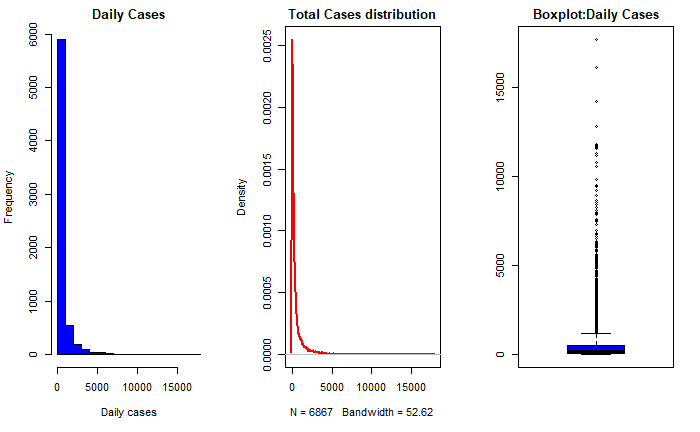

```r
summary(mydata_sorted$Daily_Cases)
```

```
   Min. 1st Qu.  Median    Mean 3rd Qu.    Max.
    0.0    51.0   174.0   544.4   509.5 17716.0
```

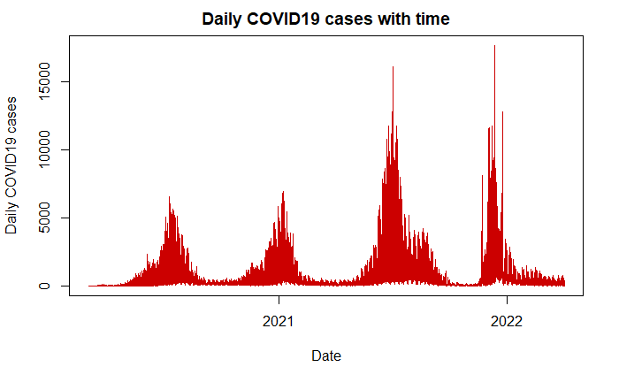

ii Daily Deaths

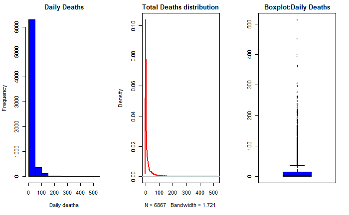

```r
summary(mydata_sorted$Daily_Deaths)
```

```
   Min. 1st Qu.  Median    Mean 3rd Qu.    Max.
   0.00    0.00    3.00   14.69   15.00  515.00
```

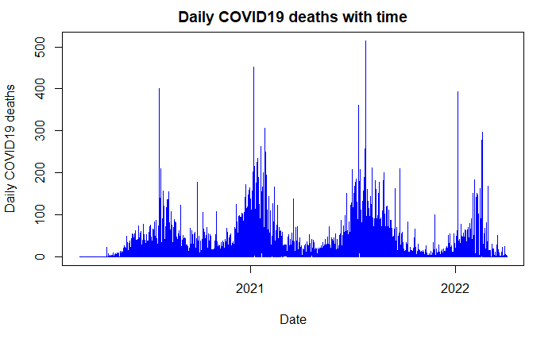

iii Total Recoveries

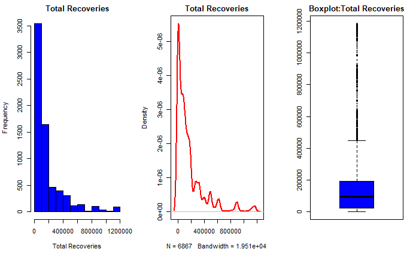

iv Total Cases

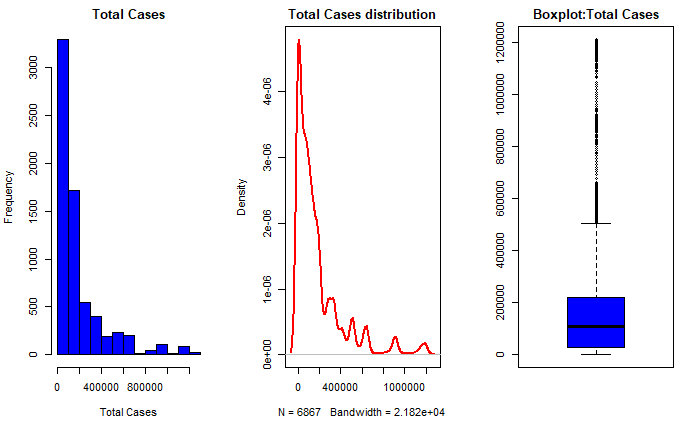

v Total Deaths

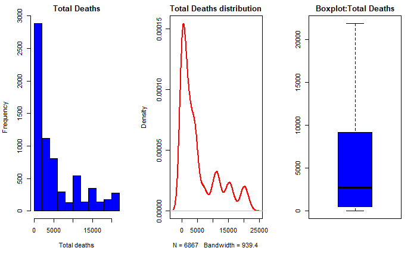

vi Daily Cases 14 day average

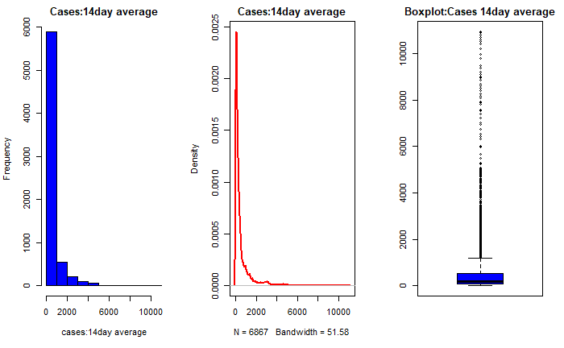

vii Deaths 14 day average

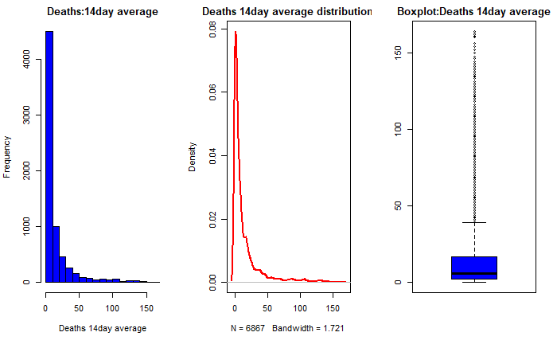

MULTIVARIATE ANALYSIS

```r
by(mydata_sorted$Total_Cases,mydata_sorted$Province,summary)
```

```
mydata_sorted$Province: Eastern Cape
   Min. 1st Qu.  Median    Mean 3rd Qu.    Max.
      0   86983  194659  177511  289466  345335
------------------------------------------------------------------
mydata_sorted$Province: Free State
   Min. 1st Qu.  Median    Mean 3rd Qu.    Max.
      0   40305   81821   91921  160519  202504
------------------------------------------------------------------
mydata_sorted$Province: Gauteng
   Min. 1st Qu.  Median    Mean 3rd Qu.    Max.
      0  213537  410392  516154  915427 1210873
------------------------------------------------------------------
mydata_sorted$Province: KwaZulu-Natal
   Min. 1st Qu.  Median    Mean 3rd Qu.    Max.
      0  115227  332445  298916  509890  661303
------------------------------------------------------------------
mydata_sorted$Province: Limpopo
   Min. 1st Qu.  Median    Mean 3rd Qu.    Max.
      0   13848   62821   64963  121736  155881
------------------------------------------------------------------
mydata_sorted$Province: Mpumalanga
   Min. 1st Qu.  Median    Mean 3rd Qu.    Max.
      0   25255   73416   80813  150540  193356
------------------------------------------------------------------
mydata_sorted$Province: North West
   Min. 1st Qu.  Median    Mean 3rd Qu.    Max.
      0   26490   62520   79996  149002  193115
------------------------------------------------------------------
mydata_sorted$Province: Northern Cape
   Min. 1st Qu.  Median    Mean 3rd Qu.    Max.
      0   12314   35213   46331   90068  108953
------------------------------------------------------------------
mydata_sorted$Province: Western Cape
   Min. 1st Qu.  Median    Mean 3rd Qu.    Max.
      0  107478  280674  289761  508451  651634
```

```r
by(mydata_sorted$Total_Deaths,mydata_sorted$Province,summary)
```

```
mydata_sorted$Province: Eastern Cape
   Min. 1st Qu.  Median    Mean 3rd Qu.    Max.
      0    3010   11336    8847   14728   16588
------------------------------------------------------------------
mydata_sorted$Province: Free State
   Min. 1st Qu.  Median    Mean 3rd Qu.    Max.
      0     802    3537    3585    6630    7654
------------------------------------------------------------------
mydata_sorted$Province: Gauteng
   Min. 1st Qu.  Median    Mean 3rd Qu.    Max.
      0    3846   10098   10215   19302   20661
------------------------------------------------------------------
mydata_sorted$Province: KwaZulu-Natal
   Min. 1st Qu.  Median    Mean 3rd Qu.    Max.
      0    2351    9892    8055   14506   16048
------------------------------------------------------------------
mydata_sorted$Province: Limpopo
   Min. 1st Qu.  Median    Mean 3rd Qu.    Max.
      0     257    2040    1989    3949    4586
------------------------------------------------------------------
mydata_sorted$Province: Mpumalanga
   Min. 1st Qu.  Median    Mean 3rd Qu.    Max.
      0     416    1316    1286    1958    4705
------------------------------------------------------------------
mydata_sorted$Province: North West
   Min. 1st Qu.  Median    Mean 3rd Qu.    Max.
      0     290    1323    1901    4085    4721
------------------------------------------------------------------
mydata_sorted$Province: Northern Cape
   Min. 1st Qu.  Median    Mean 3rd Qu.    Max.
      0     150     791    1090    2169    3218
------------------------------------------------------------------
mydata_sorted$Province: Western Cape
   Min. 1st Qu.  Median    Mean 3rd Qu.    Max.
      0    4005   11391   10703   19657   21869
```

Though Gauteng has had the highest number of total COVID19 cases, more people have died due to COVID19 related complications in Western Cape.

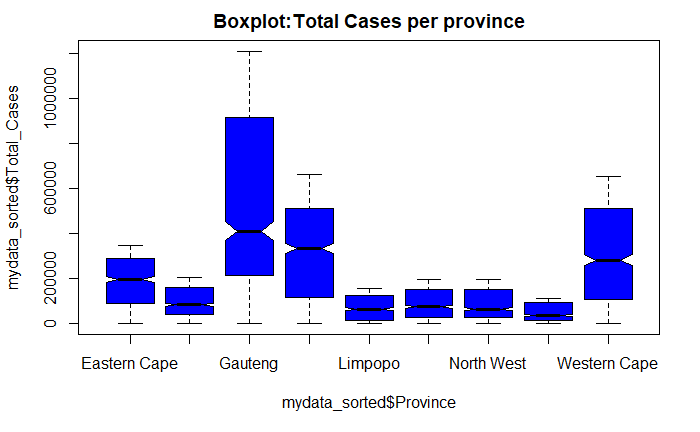

```r
boxplot(mydata_sorted$Total_Cases~mydata_sorted$Province,notch = T,col="blue",main =
          "Boxplot:Total Cases per province")
```

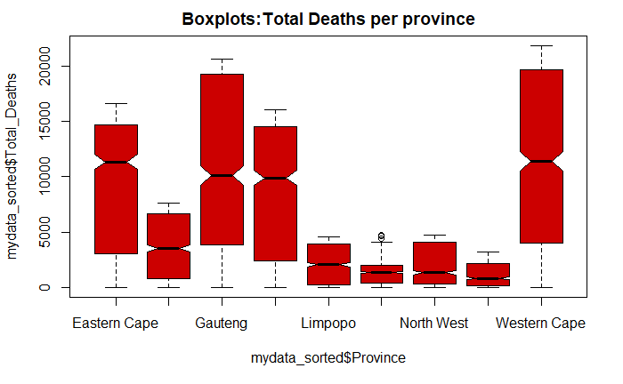

The boxplots above give a relative comparison of the total cases and total deaths for all the provinces.

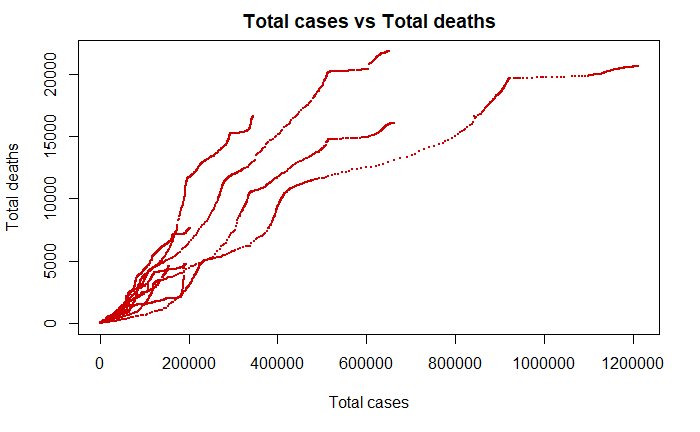

```r
plot(mydata_sorted$Total_Cases,mydata_sorted$Total_Deaths,
     pch = 19,
     cex = 0.3,
     col = "#cc0000",
     main = "Total cases vs Total deaths",
     xlab = "Total cases",
     ylab = "Total deaths")
```

Scatter plots: Total cases vs Total deaths per province 1. Gauteng

```r
gauteng = subset(mydata_sorted,Province == "Gauteng")
View(gauteng)
```

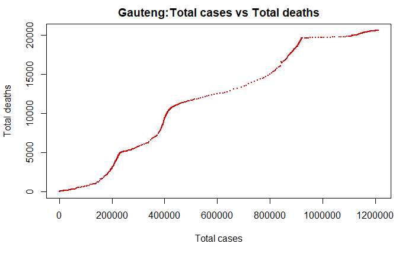

```r
plot(gauteng$Total_Cases,gauteng$Total_Deaths,
     pch = 19,
     cex = 0.3,
     col = "#cc0000",
     main = "Gauteng:Total cases vs Total deaths",
     xlab = "Total cases",
     ylab = "Total deaths")
```

We can define death rate as the number of deaths divided by the number of cases.In this case we took the maximum total of deaths divided by the maximum total cases. The death rate is 0.0170. This variable enables a comparison of the number of deaths as per number of cases to be compared province by province. This can probably give an indication of the quality of care for covid19 patients across provinces. For Gauteng the death rate is 0.017. Even though Gauteng recorded the highest total infections and is currently second highest in total deaths but the number of deaths per cases is lower than other provinces for instance Eastern Cape which is: 0.048.

2. Eastern Cape

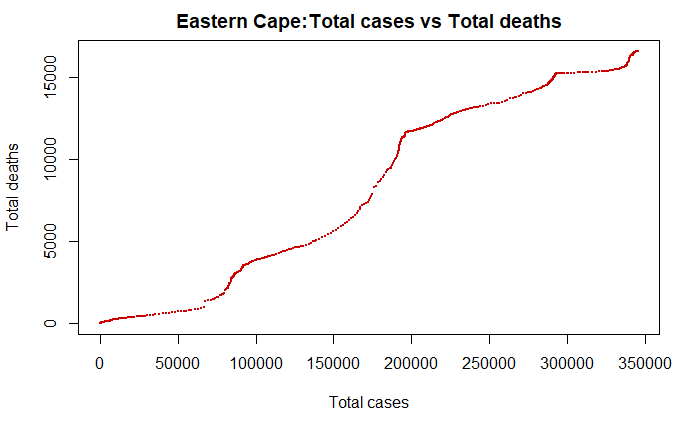

3. Free State

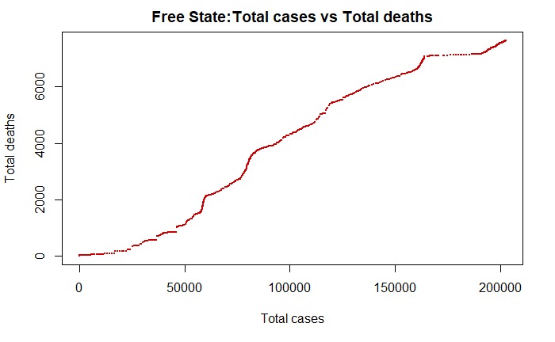

```r
FS = subset(mydata_sorted,Province == "Free State")
plot(FS$Total_Cases,FS$Total_Deaths,
     pch = 19,
     cex = 0.3,
     col = "#cc0000",
     main = "Free State:Total cases vs Total deaths",
     xlab = "Total cases",
     ylab = "Total deaths")
```

```r
NA
NA
```

Death rate = 0.0378

4. KwaZulu-Natal

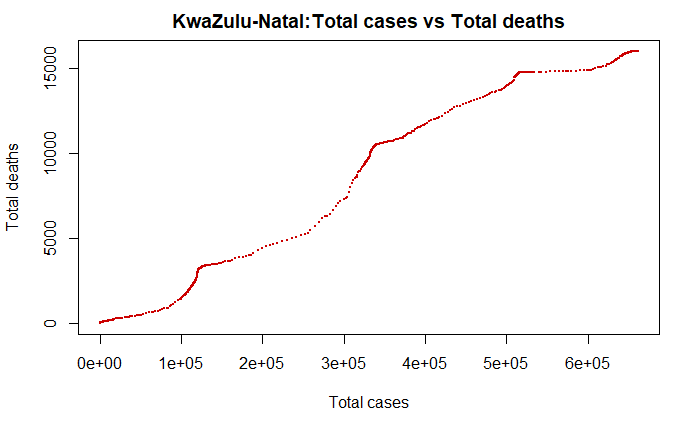

Death rate = 0.0243

5. Mpumalanga

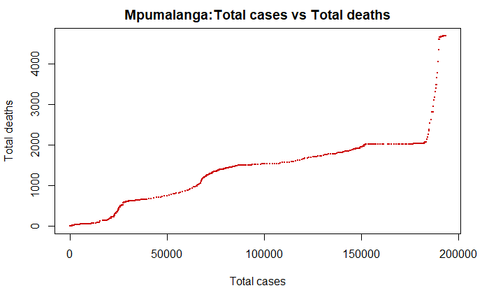

```r
MP = subset(mydata_sorted,Province == "Mpumalanga")
plot(MP$Total_Cases,MP$Total_Deaths,
     pch = 19,
     cex = 0.3,
     col = "#cc0000",
     main = "Mpumalanga:Total cases vs Total deaths",
     xlab = "Total cases",
     ylab = "Total deaths")
```

Death rate = 0.0243

6. Limpopo

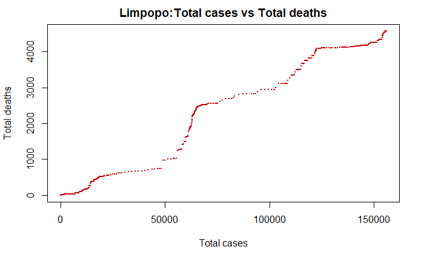

```r
LP = subset(mydata_sorted,Province == "Limpopo")
plot(LP$Total_Cases,LP$Total_Deaths,
     pch = 19,
     cex = 0.3,
     col = "#cc0000",
     main = "Limpopo:Total cases vs Total deaths",
     xlab = "Total cases",
     ylab = "Total deaths")
```

Death rate = 0.0294

7. North West

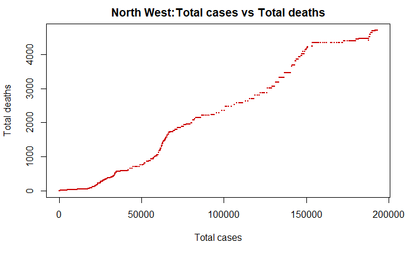

```r
NW = subset(mydata_sorted,Province == "North West")
plot(NW$Total_Cases,NW$Total_Deaths,
     pch = 19,
     cex = 0.3,
     col = "#cc0000",
     main = "North West:Total cases vs Total deaths",
     xlab = "Total cases",
     ylab = "Total deaths")
```

Death rate = 0.024

8. Northern Cape

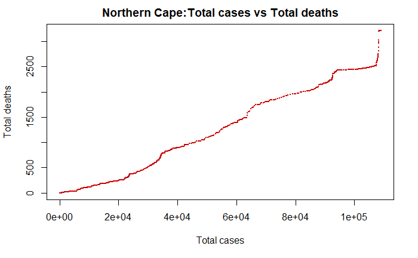

```r
NC = subset(mydata_sorted,Province == "Northern Cape")
plot(NC$Total_Cases,NC$Total_Deaths,
     pch = 19,
     cex = 0.3,
     col = "#cc0000",
     main = "Northern Cape:Total cases vs Total deaths",
     xlab = "Total cases",
     ylab = "Total deaths")
```

Death rate = 0.0295

9. Western Cape

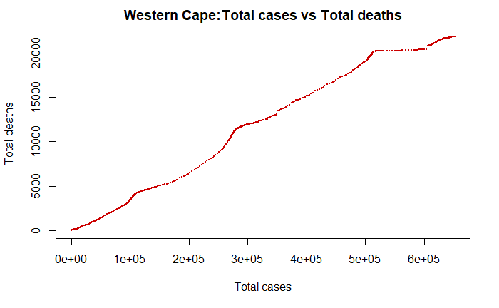

```r
WC = subset(mydata_sorted,Province == "Western Cape")
plot(WC$Total_Cases,WC$Total_Deaths,
     pch = 19,
     cex = 0.3,
     col = "#cc0000",
     main = "Western Cape:Total cases vs Total deaths",
     xlab = "Total cases",
     ylab = "Total deaths")
```

Death rate = 0.0336

3. DATA VISUALIZATION USING TABLEAU

(i)Total confirmed cases and deaths over time dashboard: https://public.tableau.com/app/profile/mufaro.chinake/viz/SouthAfricaCOVID19ConfirmedCases/Dashboard1

2. Daily cases and deaths over time https://public.tableau.com/app/profile/mufaro.chinake/viz/SouthAfricaCOVID19DailyCasesandDeaths/Dashboard1